# Cancer Mortality

アセット･マネジメント･コンサルティング株式会社 http://am-consulting.co.jp

2017-01-03 16:00:28

- アセット･マネジメント･コンサルティング株式会社 http://am-consulting.co.jp
- SaECaNet http://saecanet.com/
- Olive http://olive.saecanet.com/
- twitter https://twitter.com/AMC2_Japan

本ページへのリンクを共有:[Tweet](https://twitter.com/share)

- タイトル : 人口動態統計によるがん死亡データ:全国年齢階級別死亡率(対人口10万人),部位,性,死亡年別
- データ出所 : 国立がん研究センターがん情報サービス「がん登録・統計」
- Source http://ganjoho.jp/reg_stat/statistics/dl/index.html
- Source http://ganjoho.jp/reg_stat/statistics/qa_words/statistics_terminology01.html
- 以下は国立がん研究センターWebサイトからの引用

> **死亡率(しぼうりつ)**

> ある集団に属する人のうち、一定期間中に死亡した人の割合。日本人全体の死亡率の場合、通常1年単位で算出され、「人口10万人のうち何人死亡したか」で表現されます。  
> 200X年の死亡率(粗死亡率)= 200X年に死亡した日本人の数/200X年の日本人人口 × 100000  
> 死亡率と混同されやすい用語に「致命率」があります。  
> これは、ある病気になった人のうち、その病気が原因で死亡した人の割合です。

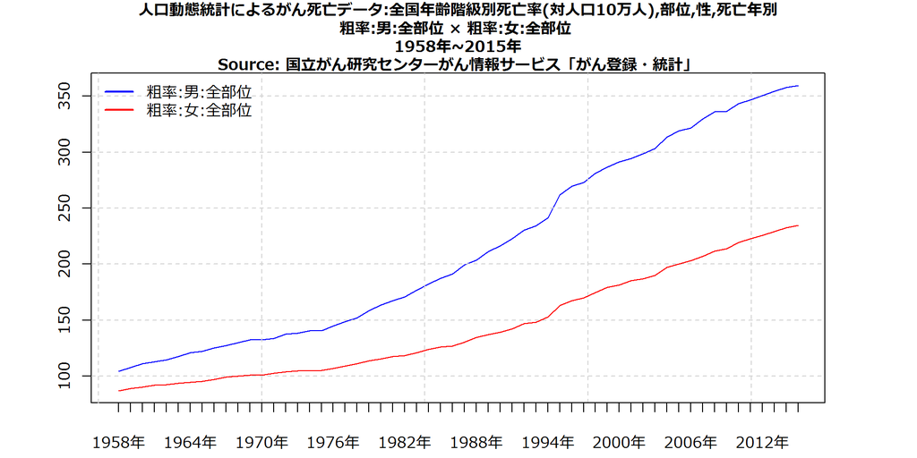

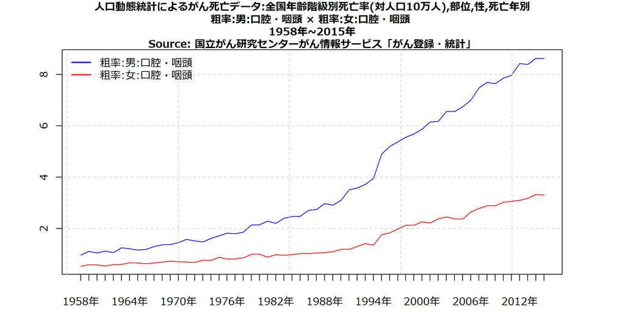

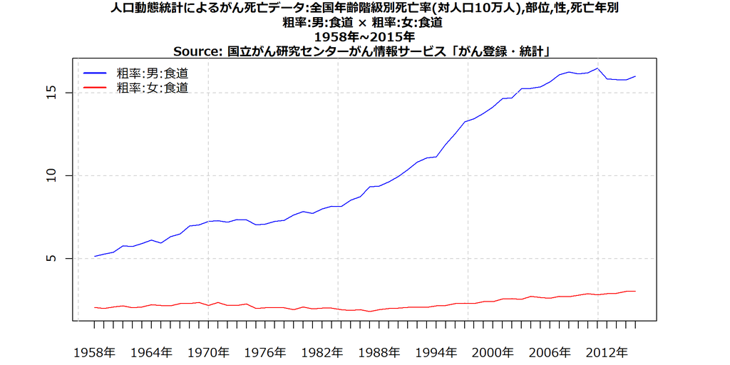

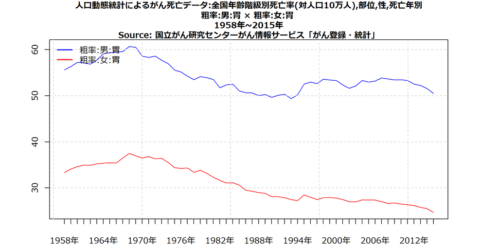

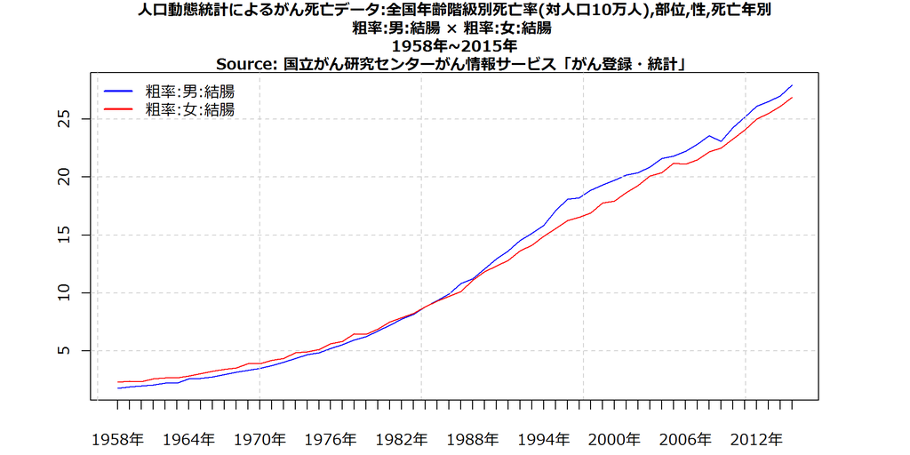

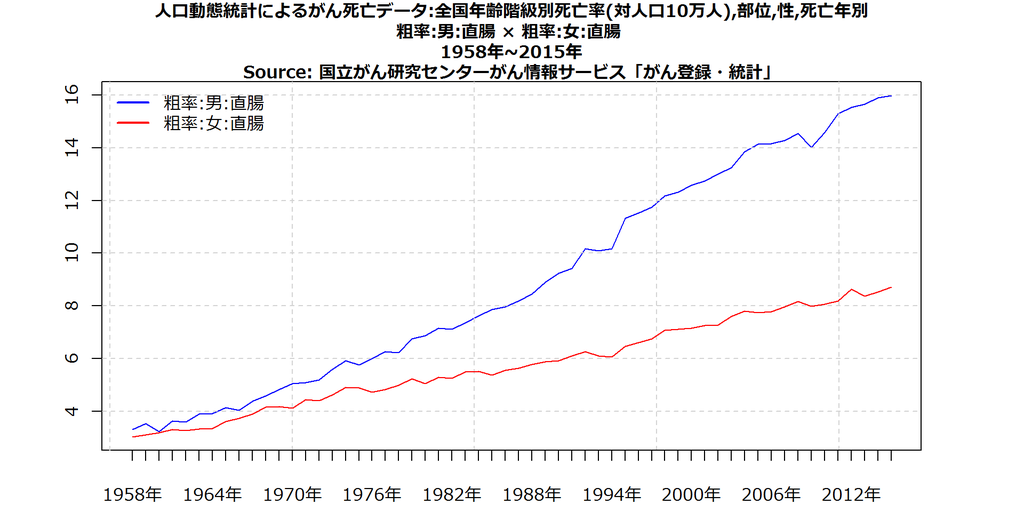

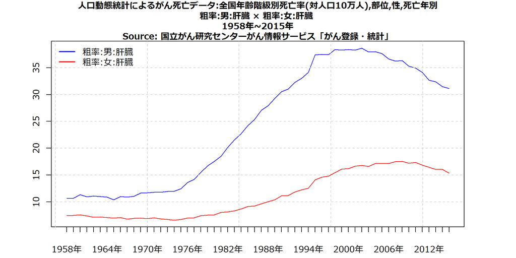

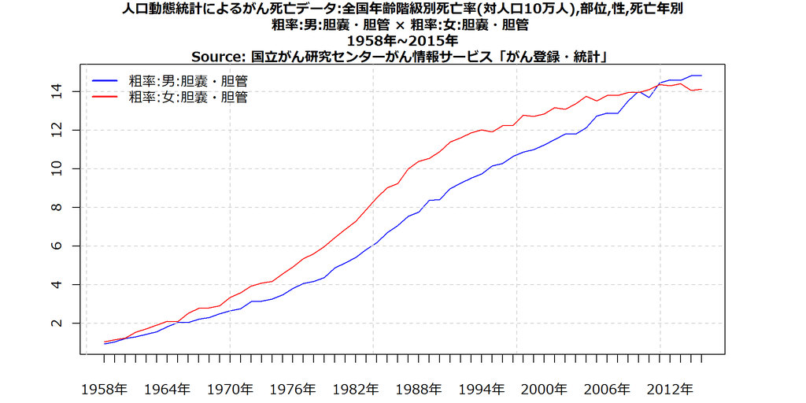

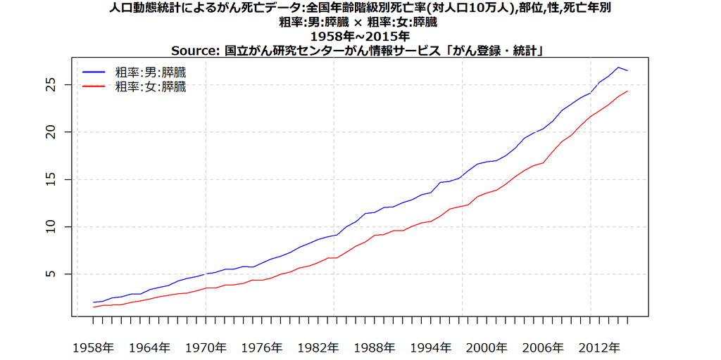

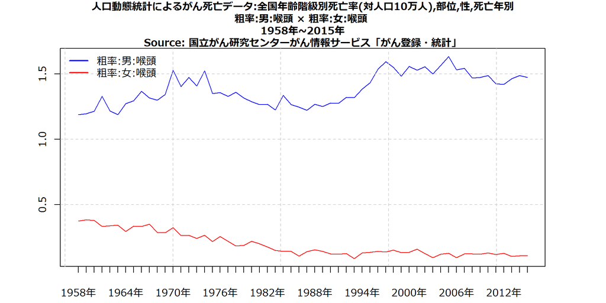

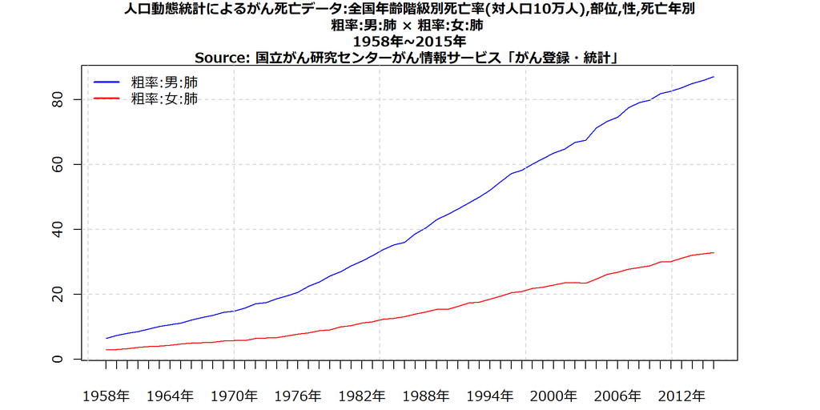

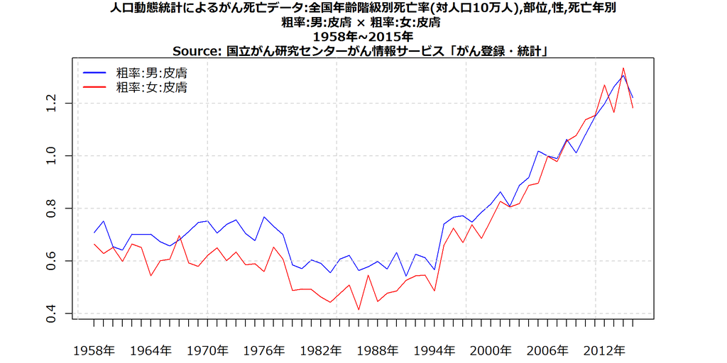

[14 more figures not shown]

| ID | Item | 2011年 | 2012年 | 2013年 | 2014年 | 2015年 |
| --- | --- | --- | --- | --- | --- | --- |
| 1 | 粗率:男:全部位 | 346.9155 | 350.7533 | 354.6154 | 357.7874 | 359.715 |
| 2 | 0-4歳:男:全部位 | 1.783724 | 2.168224 | 1.956358 | 2.004539 | 1.66134 |
| 3 | 5-9歳:男:全部位 | 1.97274 | 1.857247 | 2.021316 | 2.340267 | 2.260496 |
| 4 | 10-14歳:男:全部位 | 2.063915 | 2.011398 | 2.003396 | 2.238292 | 1.821157 |
| 5 | 15-19歳:男:全部位 | 3.208036 | 3.194263 | 2.906597 | 3.16414 | 2.798025 |
| 6 | 20-24歳:男:全部位 | 4.335443 | 3.304459 | 3.375527 | 3.120936 | 3.715089 |
| 7 | 25-29歳:男:全部位 | 4.789916 | 4.806867 | 4.40658 | 4.479419 | 4.766088 |
| 8 | 30-34歳:男:全部位 | 8.237929 | 7.842633 | 6.848228 | 8.26357 | 7.118011 |
| 9 | 35-39歳:男:全部位 | 13.45005 | 13.49745 | 13.46876 | 13.05453 | 12.43061 |
| 10 | 40-44歳:男:全部位 | 26.22845 | 26.82462 | 25.54865 | 24.70396 | 24.88612 |

[output cut: 864 more lines]

#### 前年差(単位:ポイント)

| Item | 2009年 | 2010年 | 2011年 | 2012年 | 2013年 | 2014年 | 2015年 |
| --- | --- | --- | --- | --- | --- | --- | --- |
| 粗率:男:全部位 | 0.4622795 | 6.9838508 | 3.5192815 | 3.8377974 | 3.8621085 | 3.1719539 | 1.9276001 |
| 0-4歳:男:全部位 | -0.5776159 | 0.4695781 | -0.2615233 | 0.3845008 | -0.2118661 | 0.0481804 | -0.3431988 |
| 5-9歳:男:全部位 | -0.3403163 | -0.0016618 | 0.0373561 | -0.1154934 | 0.1640688 | 0.3189518 | -0.0797716 |
| 10-14歳:男:全部位 | -0.6488305 | 0.4694903 | -0.0264819 | -0.0525169 | -0.0080023 | 0.2348964 | -0.4171352 |
| 15-19歳:男:全部位 | -0.1867066 | -0.1174358 | 0.2045358 | -0.0137729 | -0.2876664 | 0.2575428 | -0.3661152 |
| 20-24歳:男:全部位 | 0.0175376 | 0.456566 | 0.1848689 | -1.0309836 | 0.071068 | -0.2545912 | 0.5941523 |
| 25-29歳:男:全部位 | -1.3799733 | 1.2925867 | -0.6177864 | 0.016951 | -0.4002865 | 0.0728384 | 0.286669 |
| 30-34歳:男:全部位 | -0.2457626 | -0.917494 | 0.5585623 | -0.3952963 | -0.9944046 | 1.4153416 | -1.1455595 |
| 35-39歳:男:全部位 | -0.4228999 | -1.927033 | 0.7842775 | 0.0474018 | -0.0286964 | -0.4142282 | -0.623914 |
| 40-44歳:男:全部位 | 0.1106043 | -1.1689717 | -0.8149362 | 0.5961762 | -1.2759703 | -0.8446934 | 0.1821573 |
| 45-49歳:男:全部位 | -4.2154449 | -1.4756085 | -2.3353472 | -1.8008153 | -0.1338757 | -2.0906313 | -3.2308147 |
| 50-54歳:男:全部位 | -5.2270979 | -8.2340053 | -5.4552103 | -4.7607776 | -0.3274764 | -10.043967 | -3.7614602 |
| 55-59歳:男:全部位 | -8.705743 | -12.195928 | -11.219786 | -9.528573 | -5.830988 | -12.02325 | -7.988421 |
| 60-64歳:男:全部位 | -13.269282 | -10.256817 | 6.526182 | 3.142267 | -9.452607 | -16.056656 | -20.40234 |
| 65-69歳:男:全部位 | -13.560162 | 17.166572 | 13.159628 | -27.965326 | -19.024574 | -5.509473 | -20.616339 |
| 70-74歳:男:全部位 | -52.43836 | -14.123892 | -23.810605 | -18.81631 | -13.74326 | 4.311049 | 15.526756 |
| 75-79歳:男:全部位 | -52.99928 | -32.72782 | -43.92022 | -35.79619 | -31.58404 | -27.75922 | -52.74707 |
| 80-84歳:男:全部位 | -30.45363 | 33.2098 | -41.79475 | -28.85876 | -26.90816 | -61.58763 | -44.14908 |
| 85歳以上:男:全部位 | -30.88858 | 153.30242 | -83.77553 | -37.12906 | -21.52142 | -13.34231 | 42.55151 |
| 粗率:女:全部位 | 1.912072 | 5.567264 | 3.44978 | 3.023319 | 3.559867 | 3.261522 | 2.102147 |
| 0-4歳:女:全部位 | 0.3195789 | -0.6359496 | -0.1551175 | 0.6763382 | -0.496746 | 0.0120323 | -0.299949 |
| 5-9歳:女:全部位 | 0.6056074 | -0.0813568 | -0.2647188 | -0.3948758 | 0.7033002 | -0.4067783 | -0.0390592 |
| 10-14歳:女:全部位 | 0.2160844 | 0.2485957 | -0.098732 | 0.048134 | -0.4391163 | -0.0546692 | 0.7211906 |
| 15-19歳:女:全部位 | -0.6230961 | 0.3365371 | 0.1087613 | 0.2473487 | -0.238887 | -0.5040539 | 0.543323 |
| 20-24歳:女:全部位 | 0.2635379 | -0.235055 | 0.0613595 | -0.4282274 | 0.1321416 | 0.2487581 | -0.4810455 |
| 25-29歳:女:全部位 | 0.3900514 | -0.2516911 | -0.4709489 | 0.4071265 | -0.2890177 | 0.9743317 | -0.0901258 |
| 30-34歳:女:全部位 | 0.4757846 | 0.3397943 | -0.5449771 | -0.22057 | 0.1785825 | 0.6662403 | 0.1946562 |
| 35-39歳:女:全部位 | -0.1108612 | -0.5784573 | 0.6479965 | -1.3281228 | 0.4568105 | -0.4718785 | -0.906974 |
| 40-44歳:女:全部位 | -0.127878 | -0.8398385 | -1.4828568 | 1.7370449 | -2.6475674 | 0.6747707 | -1.5521498 |
| 45-49歳:女:全部位 | -2.6499173 | -3.3919713 | 1.7473069 | -3.2198432 | 0.3242472 | -0.7440666 | -2.3382493 |

[output cut: 844 more lines]

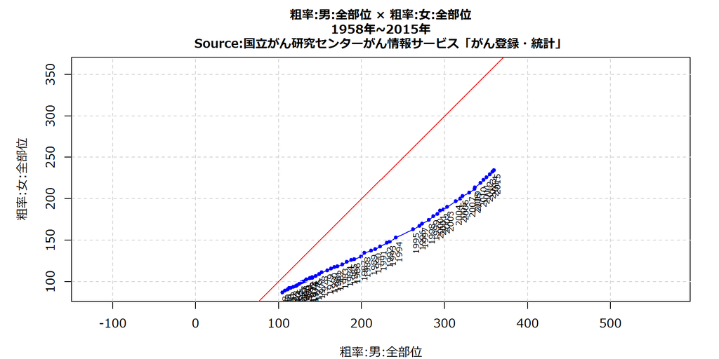

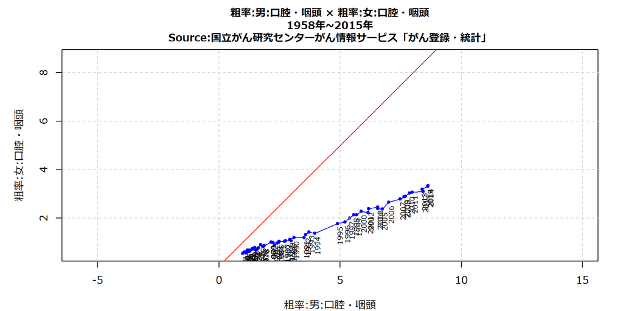

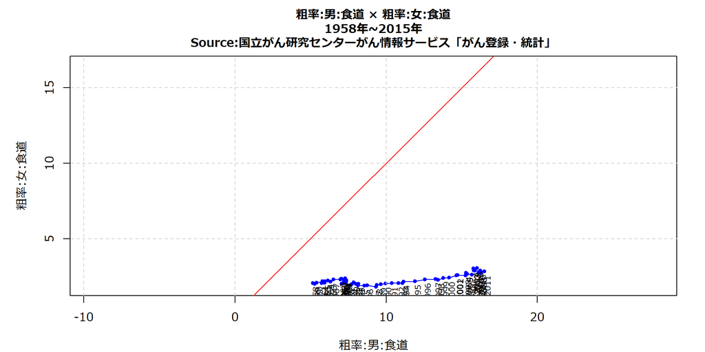

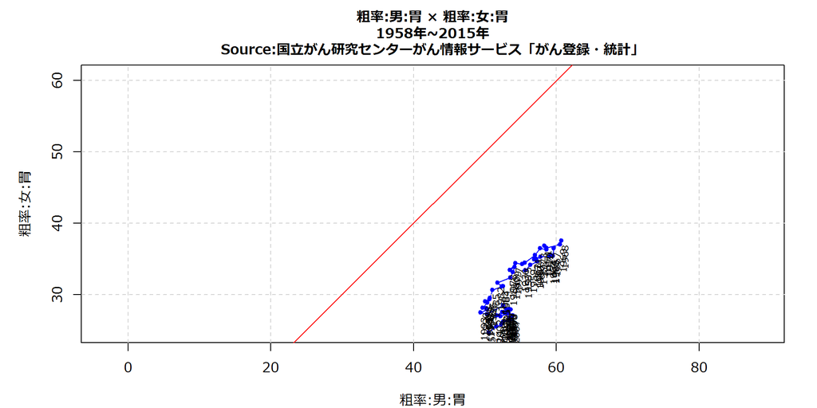

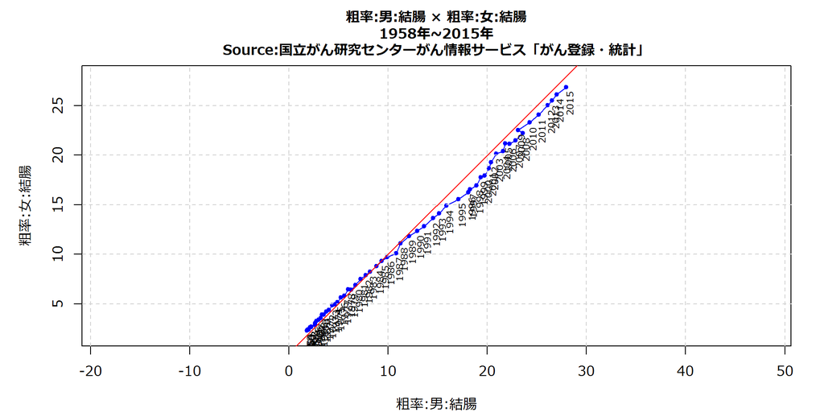

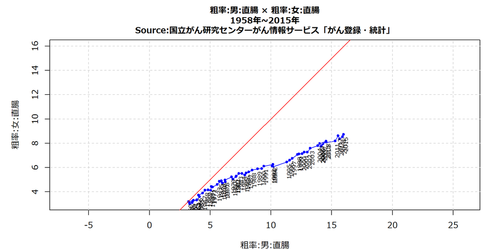

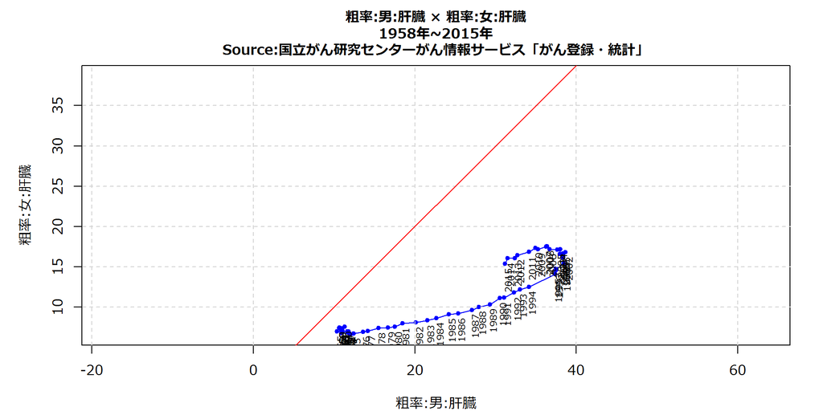

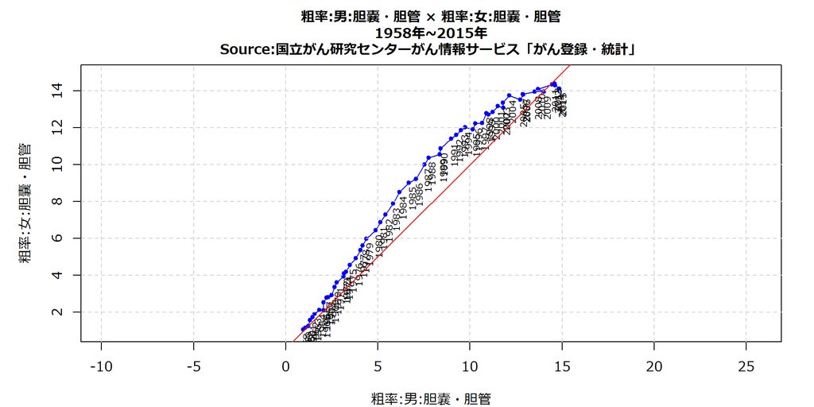

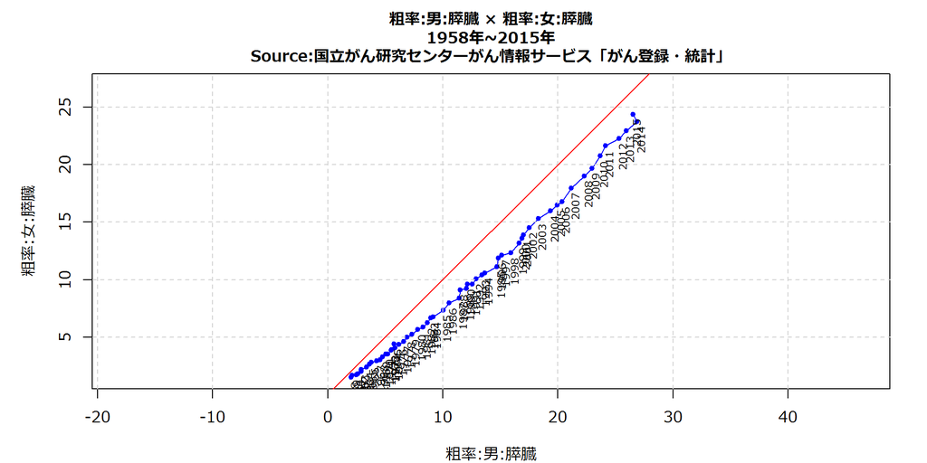

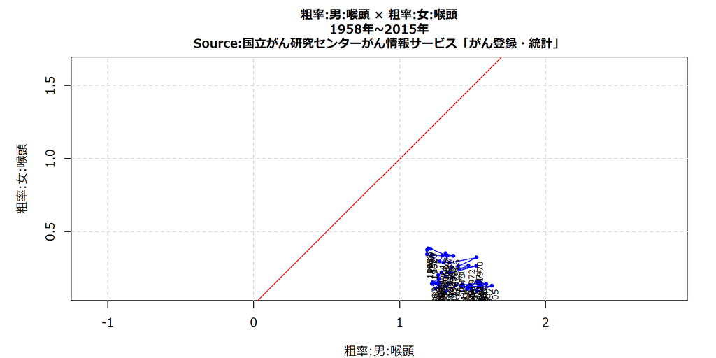

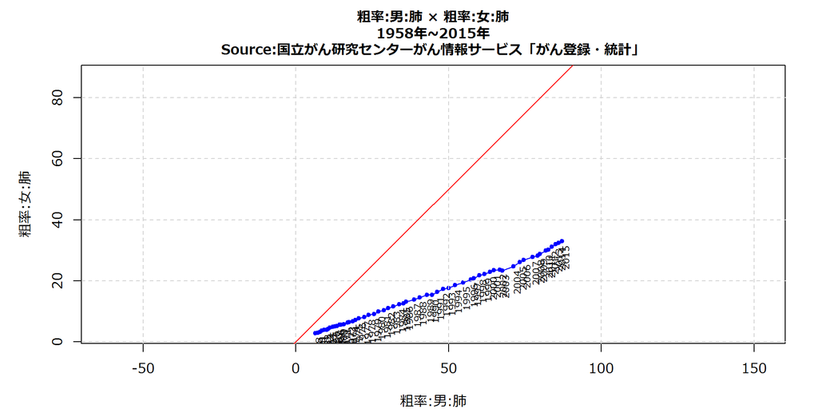

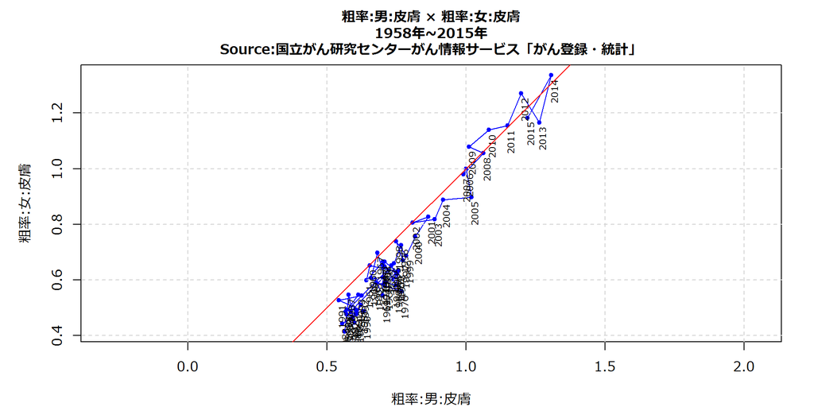

[8 more figures not shown]